# 6 Survival Analysis 1

Author

Lin Yu

Published

March 3, 2025

```r
library(dplyr)
library(ggplot2)
library(DT)
library(here)
```

## 6.1 Recap of Tutorial 5

One question left from last week:

Suppose you fit a generalized linear model with X as covariate. You are asked to calculate the effect size of X on the outcome Y comparing X=3 to X=2, and the confidence interval of the effect size:

$$g[E(Y\mid X) ] = \beta_1 + \beta_2 \mathbf{1}{\{X=2\}}+\beta_3 \mathbf{1}{\{X=3\}}$$

```r
## More about confidence interval
set.seed(1017)
x <- sample(1:3, size=1000, replace=TRUE, prob=c(0.2, 0.2, 0.6))
head(x)
```

```
[1] 3 3 2 1 1 2
```

```r
dat_x <- data.frame(x = x %>% as.factor())

design_matrix <- model.matrix(~., data = dat_x)

head(design_matrix)
```

```
  (Intercept) x2 x3
1           1  0  1
2           1  0  1
3           1  1  0
4           1  0  0
5           1  0  0
6           1  1  0
```

```r
true_coef <- c(0.5,1,2)
true_Y_linear <-   design_matrix %*% true_coef

 random_error <- rnorm(  length(true_Y_linear), mean=0,sd=1)

true_Y_cont <- true_Y_linear + random_error


  true_Y_prob <- exp(true_Y_linear)/(1+exp(true_Y_linear)) ## location param for logistic model
  true_Y_bin <- apply(true_Y_prob, 1, function(x) rbinom(n =1, size =1, prob = x)) ## for logistic model, sampling Y


sim_dat <-   data.frame(x = as.factor(x),
             true_Y_cont = true_Y_cont,
             true_Y_bin = true_Y_bin
             )

outcome_m <- glm(true_Y_bin ~ x, family = binomial("logit"), data = sim_dat)
summary(outcome_m)
```

```
Call:
glm(formula = true_Y_bin ~ x, family = binomial("logit"), data = sim_dat)

Coefficients:
            Estimate Std. Error z value Pr(>|z|)
(Intercept)   0.6792     0.1447   4.694 2.67e-06 ***
x2            1.0489     0.2541   4.128 3.65e-05 ***
x3            1.7758     0.2087   8.509  < 2e-16 ***
---
Signif. codes:  0 '***' 0.001 '**' 0.01 '*' 0.05 '.' 0.1 ' ' 1

(Dispersion parameter for binomial family taken to be 1)

    Null deviance: 834.94  on 999  degrees of freedom
Residual deviance: 760.88  on 997  degrees of freedom
AIC: 766.88

Number of Fisher Scoring iterations: 5
```

### 6.1.1 Method 1

Change the reference level:

```r
sim_dat$x <- relevel(sim_dat$x, ref = "2")

outcome_m2 <- glm(true_Y_bin ~ x, family = binomial("logit"), data = sim_dat)

summary(outcome_m2)
```

```
Call:
glm(formula = true_Y_bin ~ x, family = binomial("logit"), data = sim_dat)

Coefficients:
            Estimate Std. Error z value Pr(>|z|)
(Intercept)   1.7280     0.2088   8.274  < 2e-16 ***
x1           -1.0489     0.2541  -4.128 3.65e-05 ***
x3            0.7269     0.2574   2.824  0.00474 **
---
Signif. codes:  0 '***' 0.001 '**' 0.01 '*' 0.05 '.' 0.1 ' ' 1

(Dispersion parameter for binomial family taken to be 1)

    Null deviance: 834.94  on 999  degrees of freedom
Residual deviance: 760.88  on 997  degrees of freedom
AIC: 766.88

Number of Fisher Scoring iterations: 5
```

### 6.1.2 Method 2

Ask yourself the following questions:

- what is the estimand/goal?

$$\beta_3 - \beta_2$$

- what is the estimator?

$$\hat\beta_3 - \hat \beta_2$$

- what is the distribution of MLE estimator?

$\hat\beta_3$ and $\hat \beta_2$ follow normal distribution. (one of the nice properties of MLE estimators)

then we can easily calculate the variance of
$$\hat\beta_3 - \hat \beta_2$$
using some math.

```r
cov_matrix <- vcov(outcome_m)

var2 <- cov_matrix[2,2]
var3 <- cov_matrix[3,3]
cov_b23 <- cov_matrix[2,3]
## refer to tutorial 4 for the calculation of var(A+B)
var_b3_minus_b2 <- var2 + var3  - 2*cov_b23

var_b3_minus_b2 %>% sqrt()
```

```
[1] 0.2573678
```

```r
se <- var_b3_minus_b2 %>% sqrt()

se
```

```
[1] 0.2573678
```

the point estiamte is calculated as:

```r
point_est <- coef(outcome_m)[3]-coef(outcome_m)[2]
```

so we conclude that $\hat\beta_3 - \hat \beta_2$ follow a normal distribution with mean 0.7269048 and se 0.2573678

Finaly question, what is the relationship between $\hat\beta_3 - \hat \beta_2$ and OR??

$$log(OR) = \hat\beta_3 - \hat \beta_2$$
You can calculate the point estimate and confidence interval for the OR as well! Hooray!

## 6.2 Tutorial 6

In this and the following few tutorials, we will focus on survival analysis.

```r
library(rms)
library(survival)
str(mgus2)
```

```
'data.frame':   1384 obs. of  11 variables:
 $ id    : num  1 2 3 4 5 6 7 8 9 10 ...
 $ age   : num  88 78 94 68 90 90 89 87 86 79 ...
  ..- attr(*, "label")= chr "AGE AT mgus_sp"
 $ sex   : Factor w/ 2 levels "F","M": 1 1 2 2 1 2 1 1 1 1 ...
  ..- attr(*, "label")= chr "Sex"
  ..- attr(*, "format")= chr "$desex"
 $ dxyr  : num  1981 1968 1980 1977 1973 ...
 $ hgb   : num  13.1 11.5 10.5 15.2 10.7 12.9 10.5 12.3 14.5 9.4 ...
 $ creat : num  1.3 1.2 1.5 1.2 0.8 1 0.9 1.2 0.9 1.1 ...
 $ mspike: num  0.5 2 2.6 1.2 1 0.5 1.3 1.6 2.4 2.3 ...
  ..- attr(*, "label")= chr "SEP SPIKE AT mgus_sp"
 $ ptime : num  30 25 46 92 8 4 151 2 57 136 ...
 $ pstat : num  0 0 0 0 0 0 0 0 0 0 ...
 $ futime: num  30 25 46 92 8 4 151 2 57 136 ...
 $ death : num  1 1 1 1 1 1 1 1 0 1 ...
```

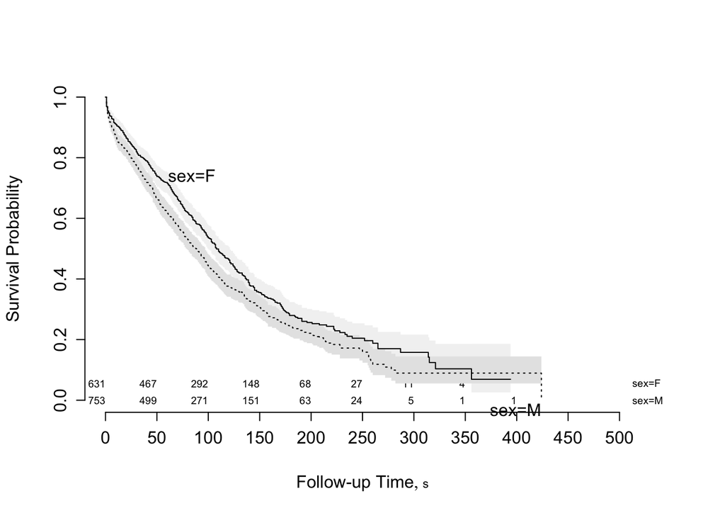

```r
fit1 <- npsurv(Surv(futime,death)~sex,data=mgus2)
library(dplyr)
tmp1 <- summary(fit1) %>% head(5) %>% unlist()
tmp <- summary(fit1)

km_dat <- data.frame(time = tmp$time,
                       risk = tmp$n.risk,
                     death = tmp$n.event) %>%
  mutate(surv_i = 1- death/risk)



survplot(fit1,n.risk=TRUE)
```

```r
print(fit1.mh <- survdiff(Surv(futime, death) ~ sex, data = mgus2))
```

```
Call:
survdiff(formula = Surv(futime, death) ~ sex, data = mgus2)

        N Observed Expected (O-E)^2/E (O-E)^2/V
sex=F 631      423      471      4.88      9.67
sex=M 753      540      492      4.67      9.67

 Chisq= 9.7  on 1 degrees of freedom, p= 0.002
```

```r
summary(fit1,times=12) # time is in months
```

```
Call: npsurv(formula = Surv(futime, death) ~ sex, data = mgus2)

                sex=F
        time       n.risk      n.event     survival      std.err lower 95% CI
     12.0000     569.0000      61.0000       0.9032       0.0118       0.8804
upper 95% CI
      0.9266

                sex=M
        time       n.risk      n.event     survival      std.err lower 95% CI
      12.000      646.000      112.000        0.851        0.013        0.826
upper 95% CI
       0.877
```

```r
## risk difference at year 1
RD <- 0.9032- 0.851
RD + 1.96*sqrt(0.0118^2 +0.013^2)
```

```
[1] 0.08661126
```

```r
RD - 1.96*sqrt(0.0118^2 +0.013^2)
```

```
[1] 0.01778874
```

we know that logHR follows a normal distribution. So the confidence interval for HR could be calculated as:

$$exp(logHR ± 1.96 \cdot se_{logHR}) = exp(logHR)\cdot exp(± 1.96 \cdot se_{logHR}) = HR \cdot exp(± 1.96 \cdot se_{logHR})$$

```r
## HR
## HR <- (obs1/exp1)/(obs2/exp2)
HR <- (423/471)/(540/492)

HR
```

```
[1] 0.818259
```

```r
## variance_logHR <- (1/exp1) + (1/exp2)
se_logHR <- sqrt( (1/471) +(1/492) )


## lower bound
HR *exp(-1.96*se_logHR)
```

```
[1] 0.7211367
```

```r
## 95% CI
## upper bound
HR *exp(1.96*se_logHR)
```

```
[1] 0.9284618
```